# MPiS - Projekt zaliczeniowy

2022-05-19

## Dane “CNNpred” UCI Machine Learning Repository

*Zebrane dane przedstawiają codzienne zmiany wskaźników technicznych dotyczących indexu S&P 500, w skład którego wchodzi 500 spółek o największej kapitalizacji, notowanych na amerykańskich giełdach NYSE i NASDAQ.*

Źródło: [Ehsan Hoseinzade, a Ph.D. student of computer science at Simon Fraser University. ehoseinz ‘@’ sfu.ca](https://archive.ics.uci.edu/ml/datasets/CNNpred%3A+CNN-based+stock+market+prediction+using+a+diverse+set+of+variables)

## wykres notowań S&P 500 z lat 2010 - 2017

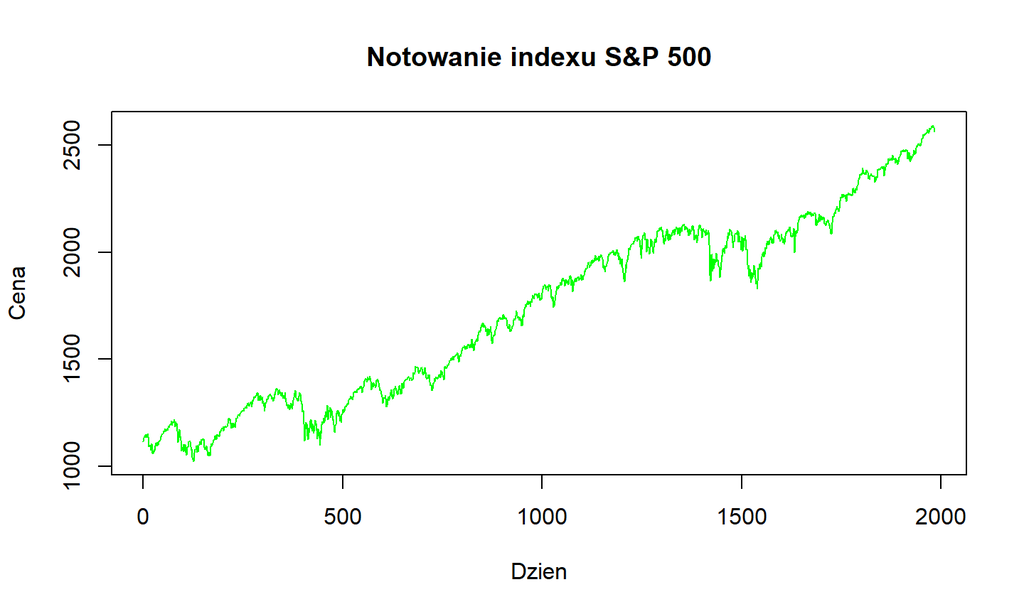

## Statystyki opisowe ruchu ceny indexu

Minimum:

```
## [1] 1022.58
```

Maksimum:

```
## [1] 2594.38
```

Średnia cena:

```
## [1] 1731.975
```

Mediana:

```
## [1] 1791.075
```

## Statystyki opisowe ruchu ceny indexu 2

Kwartyle:

```
##       0%      25%      50%      75%     100%
## 1022.580 1325.682 1791.075 2081.265 2594.380
```

Rozstęp

```
## [1] 1571.8
```

Rozstęp międzykwartylny

```
##      75%
## 755.5826
```

Odchylenie przeciętne od mediany

```
## [1] 554.9816
```

## Statystyki opisowe ruchu ceny indexu 3

Wariancja

```
## [1] 183213.5
```

Odchylenie standardowe

```
## [1] 428.0344
```

Błąd standardowy

```
## [1] 9.609657
```

Współczynnik zmienności

```
## [1] 0.2471365
```

## Wnioski

Wnioski na podstawie miar pozycyjnych:

Cena najmniejsza to 1022.58, a największa to 2594.38. Mediana dzieli dane na 2 połówki, gdzie wartości mniejsze lub równe 1791.07 stanowią połowę wszystkich historycznych cen. Mediana znajduje się między pierwszym (1325.682) i trzecim (2081.26) kwartylem. Średnia cena indexu wynosi 1731.97 i jest nieznacznie mniejsza od mediany.

## Wnioski (2)

Rozstęp jest równy 1571.8 i jest ponad dwukrotnie większy od rozstępu międzykwartylnego, który wynosi 755.58.

Na podstawie średniej i odchylenia stadardowego można stwierdzić, że przeciętna wartość powinna się mieścić w przedziale od 1,303.94 do 2160. Odchylenie standardowe jest duże.

Błąd statystyczny wynosi 9.60, dlatego średnia cen powinna się mieścić w przedziale od 1722.37 do 1,741.57. Współczynnik zmienności jest na poziomie 25% i świadczy o niewielkim rozrzucie danych.

## Histogram

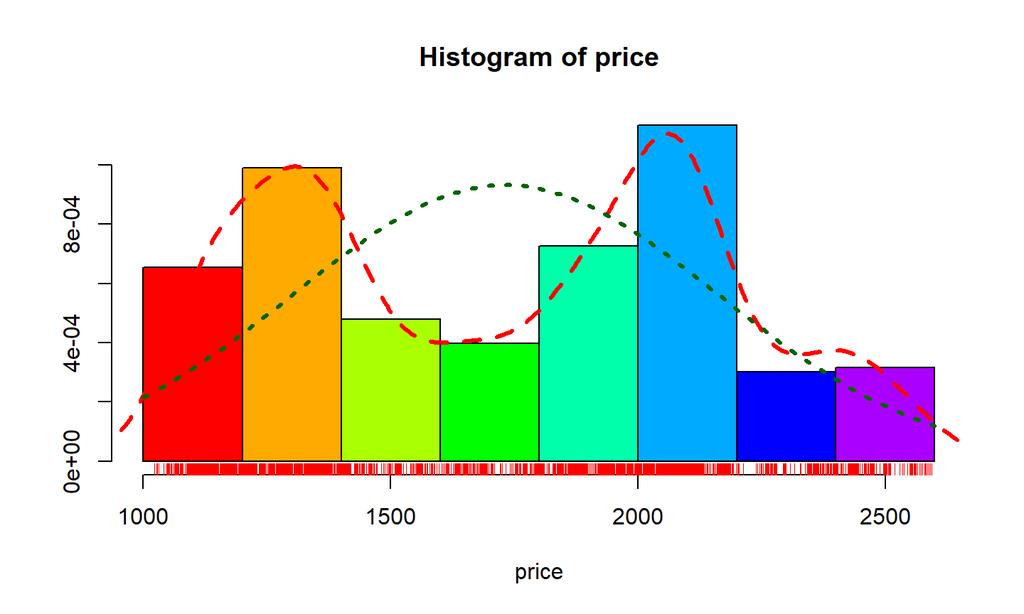

## Boxplot

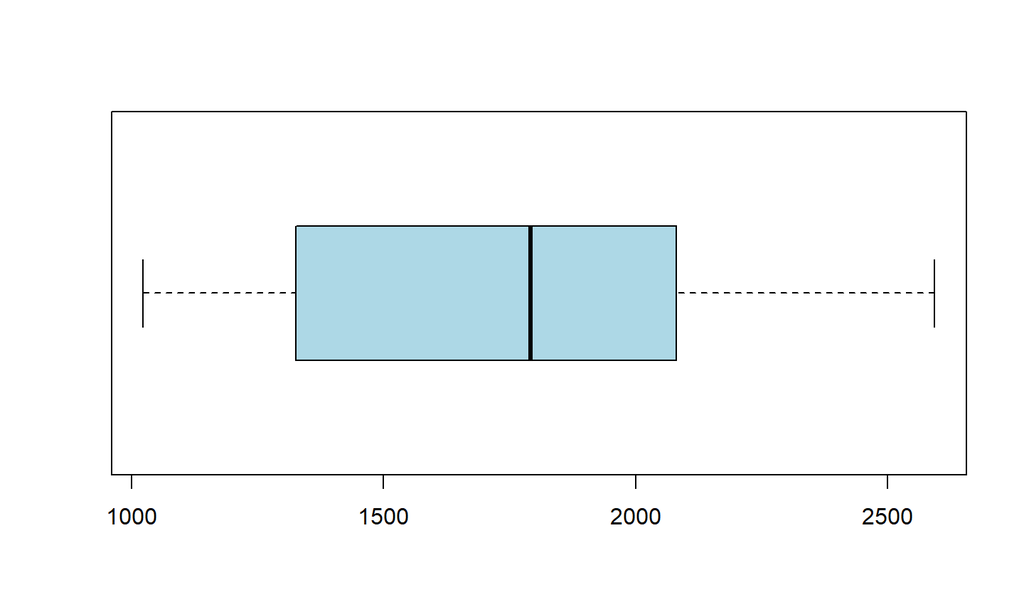